# homework3

颜帆

# 数据挖掘第三次作业

- **训练数据集：sampledata.csv**
- **测试数据集：predata.csv**

数据文件来自国内某运营商，数据已经进行了清理，数据集中的变量包括：是否流失（churn）、在网时长（tenure）、当月花费（expense）、个体的度（degree）、联系强度（tightness）、个体信息熵（entropy）、个体度的变化（chgdegree）、花费的变化（chgexpense）共8个变量。

## 1.数据清洗

读入训练数据，删除变量expense、tightness、degree中的负值，完成数据清洗；

```r
## 读入数据
library(readr)
train <- read.csv("C:\\Users\\Ivan\\Desktop\\sampledata.csv",header = T, fileEncoding = "UTF-8") # 读取训练数据
test <- read.csv("C:\\Users\\Ivan\\Desktop\\preddata.csv",header = T,fileEncoding = "UTF-8") # 读取测试数据
#dim(train)  #48393 9
#dim(test)   #47900 9

## 1.数据清洗
train <- train[ which(train$expense >= 0 & train$tightness >= 0 & train$degree >= 0),]
#dim(train)  #48289 9
test <- test[ which(test$expense >= 0 & test$tightness >= 0 & test$degree >= 0),]
#dim(test)  #47773 9
```

## 2.箱线图

绘制因变量和各个自变量的箱线图（提示：可以对右偏分布的数据取对数）； 先根据偏度判断数据是否右偏(偏度大于0即为右偏分布的数据)：

```r
#根据偏度系数判断是否右偏
library(moments)
skewness(train$tenure) #1.56 右偏
```

```
## [1] 1.562561
```

```r
skewness(train$expense) #1.09 右偏
```

```
## [1] 1.09379
```

```r
skewness(train$degree) #1.39 右偏
```

```
## [1] 1.391456
```

```r
skewness(train$tightness) #2.41 右偏
```

```
## [1] 2.405543
```

```r
skewness(train$entropy) #-0.4
```

```
## [1] -0.4003993
```

```r
skewness(train$chgexpense) #2.28 右偏
```

```
## [1] 2.280342
```

```r
skewness(train$chgdegree) #4.11 右偏
```

```
## [1] 4.106823
```

```r
##对除了entropy的变量取对数
#train 清洗后的数据；train_log为对部分变量取了log后的数据
#虽然chgdegree\chgexpense右偏，但是由于存在负值，且取对数意义不大就不进行处理
train_log <- train
train_log$tenure <- log(train$tenure)
train_log$expense <- log(train$expense)
train_log$degree <- log(train$degree)
train_log$tightness <- log(train$tightness)
```

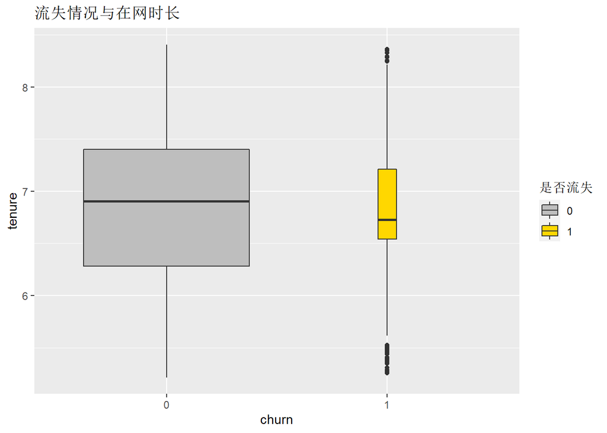

```r
##绘制箱线图
library(ggplot2)
(boxplot1 <- ggplot(train_log,aes(x = as.factor(churn), y = tenure,fill = as.factor(churn))) +
    geom_boxplot(show.legend = T, varwidth = T) +
    #theme(axis.title.x = element_text(size = 16, face ="bold"),
    #      axis.text.x = element_text(size =12, face = "bold"),
    #      axis.title.y = element_text(size = 16, face ="bold"),
    #      axis.text.y = element_text(size =12, face = "bold")) +
    scale_fill_manual("是否流失",values = c("grey", "gold")) +
    labs(x = "churn", y = "tenure", title ="流失情况与在网时长"))
```

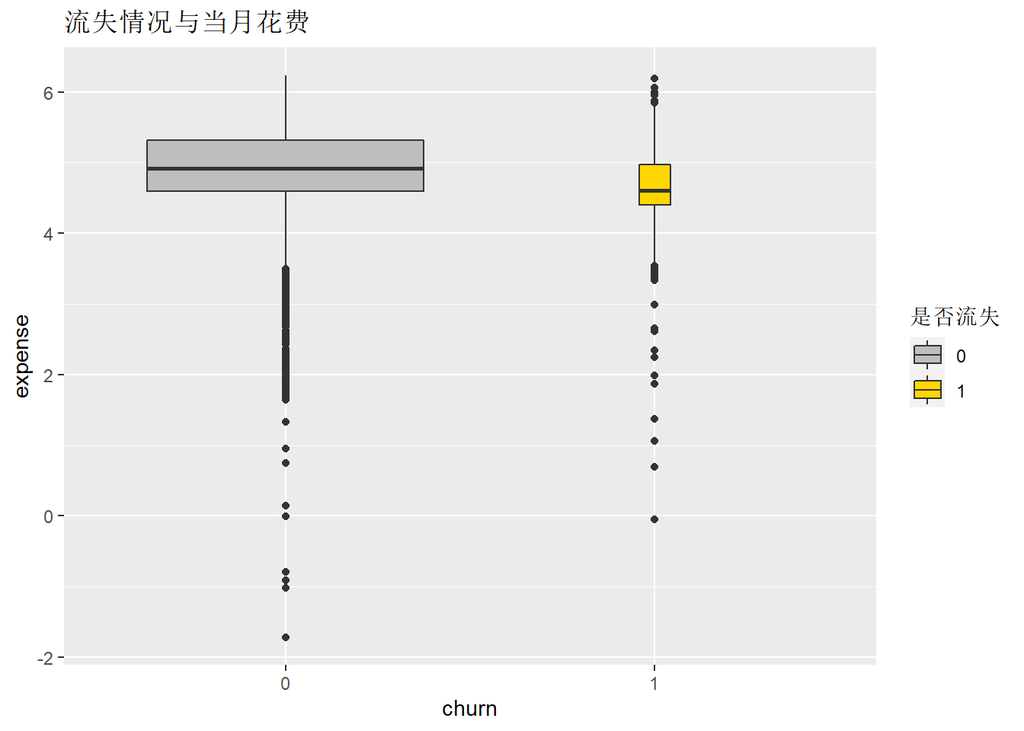

```r
(boxplot2 <- ggplot(train_log,aes(x = factor(churn), y = expense,fill = as.factor(churn))) +
    geom_boxplot(show.legend = T, varwidth = T) +
        scale_fill_manual("是否流失",values = c("grey", "gold")) +
    labs(x = "churn", y = "expense", title ="流失情况与当月花费"))
```

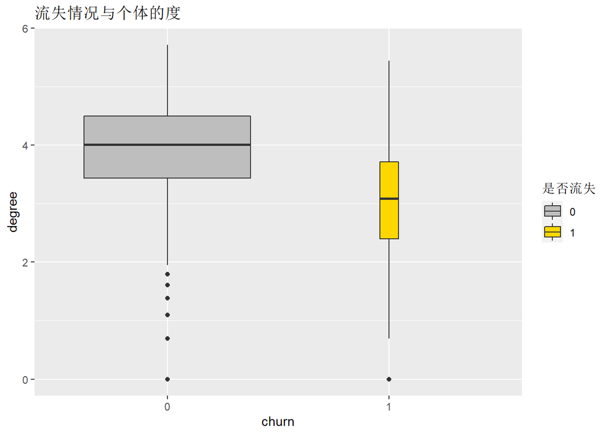

```r
(boxplot3 <- ggplot(train_log,aes(x = factor(churn), y = degree,fill = as.factor(churn))) +
        geom_boxplot(show.legend = T, varwidth = T) +
        scale_fill_manual("是否流失",values = c("grey", "gold")) +
        labs(x = "churn", y = "degree", title ="流失情况与个体的度"))
```

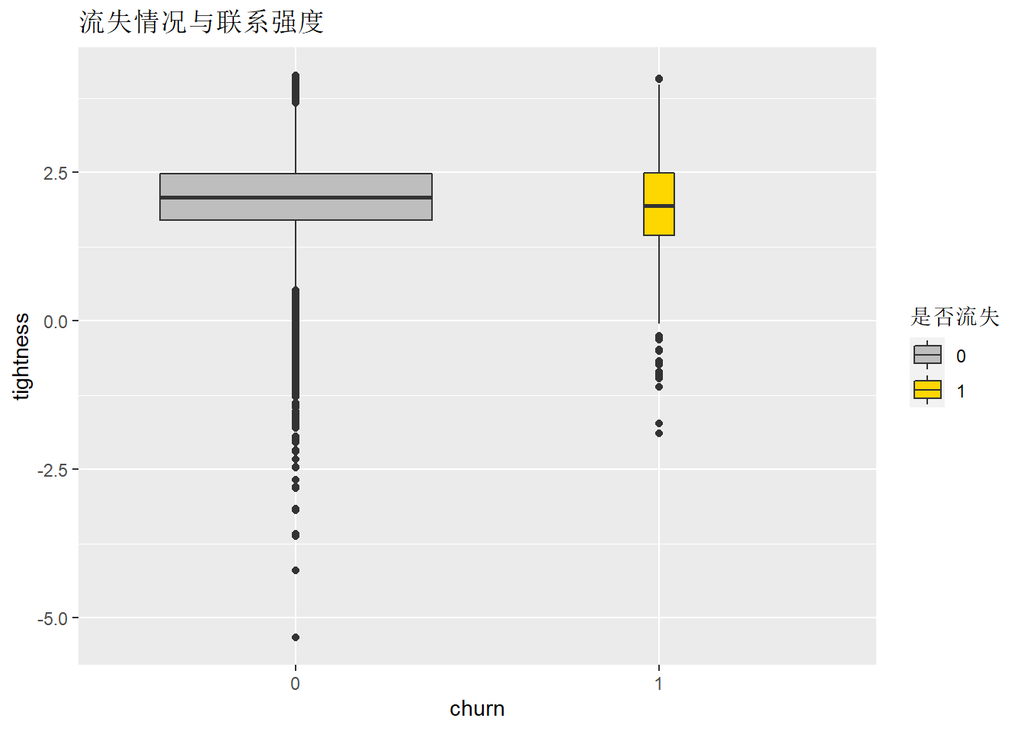

```r
(boxplot4 <- ggplot(train_log,aes(x = as.factor(churn), y = tightness,fill = as.factor(churn))) +
        geom_boxplot(show.legend = T, varwidth = T) +
        scale_fill_manual("是否流失",values = c("grey", "gold")) +
        labs(x = "churn", y = "tightness", title ="流失情况与联系强度"))
```

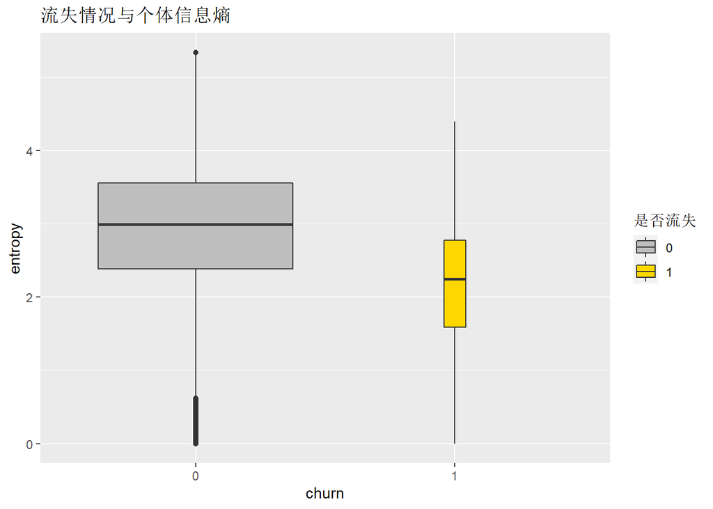

```r
(boxplot5 <- ggplot(train_log,aes(x = factor(churn), y = entropy,fill = as.factor(churn))) +
        geom_boxplot(show.legend = T, varwidth = T) +
        scale_fill_manual("是否流失",values = c("grey", "gold")) +
        labs(x = "churn", y = "entropy", title ="流失情况与个体信息熵"))
```

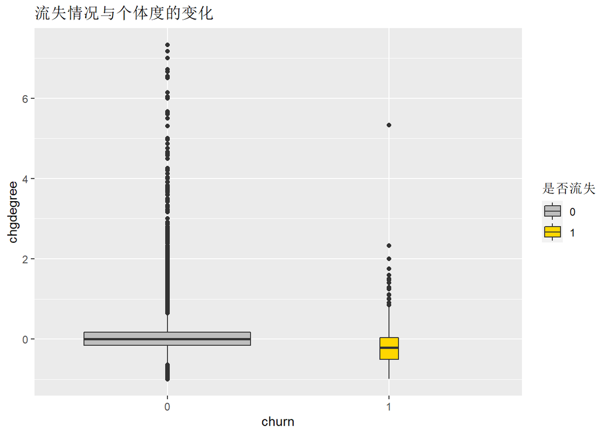

```r
(boxplot6 <- ggplot(train,aes(x = factor(churn), y = chgdegree,fill = as.factor(churn))) +
        geom_boxplot(show.legend = T, varwidth = T) +
        scale_fill_manual("是否流失",values = c("grey", "gold")) +
        #scale_y_continuous(limits = c(-2, 4))+
        labs(x = "churn", y = "chgdegree", title ="流失情况与个体度的变化"))
```

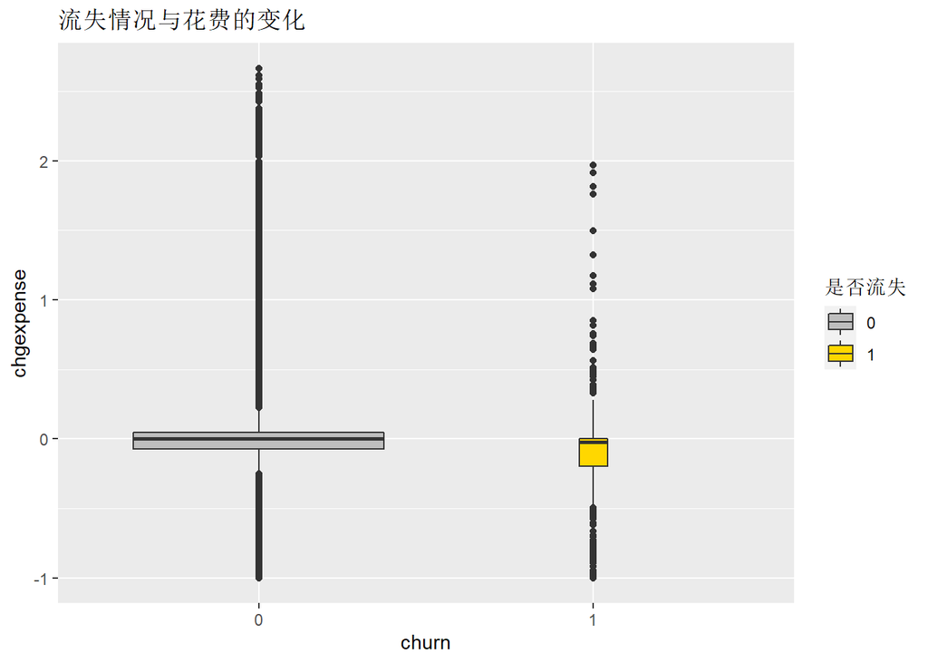

```r
(boxplot7 <- ggplot(train,aes(x = factor(churn), y = chgexpense,fill = as.factor(churn))) +
        geom_boxplot(show.legend = T, varwidth = T) +
        scale_fill_manual("是否流失",values = c("grey", "gold")) +
        #scale_y_continuous(limits = c(-1, 1),breaks = seq(-1, 1, by = 0.2))+
        labs(x = "churn", y = "chgexpense", title ="流失情况与花费的变化"))
```

## 3.数据标准化及建模

以是否流失为因变量，对自变量进行标准化（使其均值为0，方差为1，提示：在R中可使用scale函数），建立逻辑回归模型，给出系数估计结果，并对结果进行解读（提示：使用glm()函数建立逻辑回归模型）；

```r
## 数据标准化
std <- scale(train[,2:8], center = T, scale = T) #对清洗后的数据做标准化
train[,2:8] <- std
## glm
myglm0 <- glm(formula = churn ~  . -ID  ,family = binomial(), data = train)
summary(myglm0)
```

```
##
## Call:
## glm(formula = churn ~ . - ID, family = binomial(), data = train)
##
## Deviance Residuals:
##     Min       1Q   Median       3Q      Max
## -0.8878  -0.1749  -0.1199  -0.0748   4.2046
##
## Coefficients:
##             Estimate Std. Error z value Pr(>|z|)
## (Intercept) -5.05260    0.07210 -70.076  < 2e-16 ***
## tenure      -0.24775    0.06070  -4.082 4.47e-05 ***
## expense     -0.29215    0.05904  -4.949 7.47e-07 ***
## degree      -0.73977    0.13166  -5.619 1.92e-08 ***
## tightness   -0.22582    0.04247  -5.317 1.06e-07 ***
## entropy     -0.34890    0.07201  -4.845 1.26e-06 ***
## chgexpense  -0.15987    0.04890  -3.269  0.00108 **
## chgdegree   -0.38250    0.05209  -7.344 2.08e-13 ***
## ---
## Signif. codes:  0 '***' 0.001 '**' 0.01 '*' 0.05 '.' 0.1 ' ' 1
##
## (Dispersion parameter for binomial family taken to be 1)
##
##     Null deviance: 6475.6  on 48288  degrees of freedom
## Residual deviance: 5758.9  on 48281  degrees of freedom
## AIC: 5774.9
##
## Number of Fisher Scoring iterations: 8
```

```r
myglm <- step(myglm0, trace = F) #以AIC为准则筛选变量
summary(myglm)
```

```
##
## Call:
## glm(formula = churn ~ (ID + tenure + expense + degree + tightness +
##     entropy + chgexpense + chgdegree) - ID, family = binomial(),
##     data = train)
##
## Deviance Residuals:
##     Min       1Q   Median       3Q      Max
## -0.8878  -0.1749  -0.1199  -0.0748   4.2046
##
## Coefficients:
##             Estimate Std. Error z value Pr(>|z|)
## (Intercept) -5.05260    0.07210 -70.076  < 2e-16 ***
## tenure      -0.24775    0.06070  -4.082 4.47e-05 ***
## expense     -0.29215    0.05904  -4.949 7.47e-07 ***
## degree      -0.73977    0.13166  -5.619 1.92e-08 ***
## tightness   -0.22582    0.04247  -5.317 1.06e-07 ***
## entropy     -0.34890    0.07201  -4.845 1.26e-06 ***
## chgexpense  -0.15987    0.04890  -3.269  0.00108 **
## chgdegree   -0.38250    0.05209  -7.344 2.08e-13 ***
## ---
## Signif. codes:  0 '***' 0.001 '**' 0.01 '*' 0.05 '.' 0.1 ' ' 1
##
## (Dispersion parameter for binomial family taken to be 1)
##
##     Null deviance: 6475.6  on 48288  degrees of freedom
## Residual deviance: 5758.9  on 48281  degrees of freedom
## AIC: 5774.9
##
## Number of Fisher Scoring iterations: 8
```

由summary(myglm)中各参数的系数可以看出，各参数的系数均为负值，也就是说，预测该用户为流失用户的概率与各变量成反比，也就是说对一个个体，他的在线时长越长、当月花费越多、联系强度越强、个体信息熵越大就越不可能为流失用户。（按常识，个体度的变化、花费的变化越小，越不可能为流失用户，但是这个结果算出来它的系数就是负的）

## 4.预测

使用建立好的逻辑回归模型，分别对训练集和测试集进行预测，得到每个用户的预测流失概率值（提示：使用predict()函数进行预测）；

```r
## 对训练集进行预测
pred <- predict(myglm, train, type="response") ##得到每个用户的预测流失概率值
#pred_data <- as.factor(ifelse(pred>0.5,1,0))  #概率大于0.5则预测为1，认为该用户流失
#table(train$churn,pred_data) #混淆矩阵
```

```r
## 对测试集进行预测
std <- scale(test[,2:8], center = T, scale = T) #对清洗后的数据做标准化
test[,2:8] <- std

pred2 <- predict(myglm, test, type="response")
#pred_data2 <- as.factor(ifelse(pred2>0.5,1,0))
#table(test$churn,pred_data2)
```

## 5.评估

借助问题4中预测的结果，分别绘制训练集和测试集上预测结果的ROC曲线，计算相应的AUC值，并根据ROC曲线和AUC值对模型进行评价（提示：使用R包pROC中的plot.roc()函数绘制ROC曲线）。

```r
library(pROC)
```

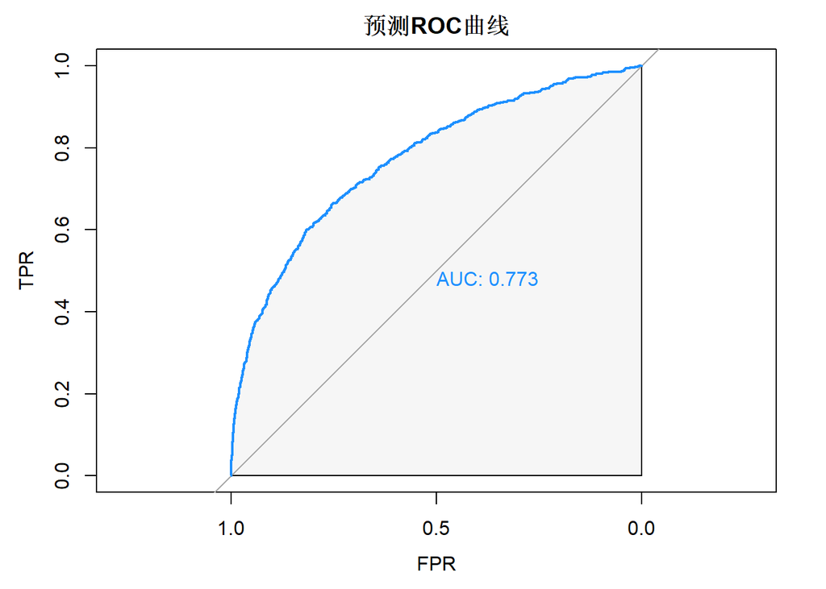

```r
# 对训练集绘制ROC曲线
plot.roc(train$churn, pred, col = "dodgerblue", print.auc=TRUE,
         auc.polygon=TRUE, auc.polygon.col="#f6f6f6", xlab = "FPR",ylab = "TPR", main = "预测ROC曲线")
```

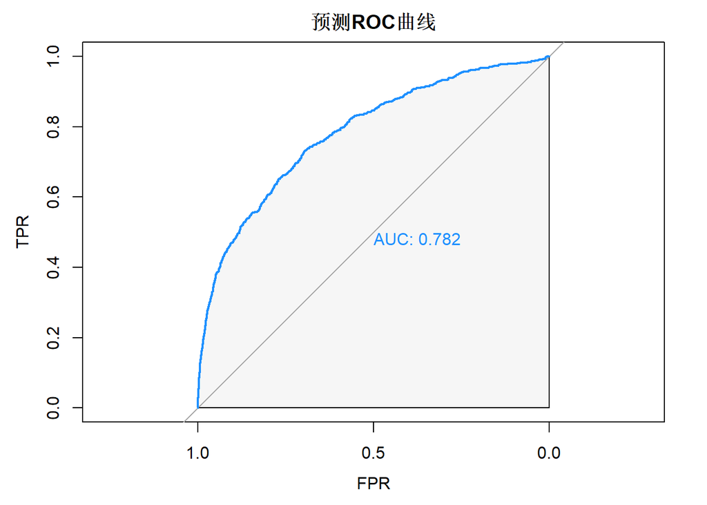

```r
# 对测试集绘制ROC曲线
plot.roc(test$churn, pred2, col = "dodgerblue", print.auc=TRUE,
         auc.polygon=TRUE, auc.polygon.col="#f6f6f6", xlab = "FPR",ylab = "TPR", main = "预测ROC曲线")
```